# Praticing Statistical Analysis & Machine Learning Techniques- Cancellation Risks in Insurance Contracts-Part 2

Antoine.T.PHAM/ Data Science Courses-DSSP 4/ Polytechnique Paris

Mai-October 2016

# Introduction

For pursuing our data project, I’m going to develop my previous work which was introduced in the part 1. According to our organization’s business needs , binary classification problem will be took into account in this section. The target will have 2 classes : 0 = no cancelled and 1 = cancelled contract. Futhermore, a set of the features concerning critical business metrics in which our business team is interested will be selected. First, I will try to show the dependency of variables with the target by using somme visual analysis. Machine larning by classification approaches then will be applied for buiding predictive models.

Let’s load somme packages

```r
library(knitr)
library(rmarkdown)
library(caret)
library(rpart)
library(randomForest)
library(ggplot2)
```

# Data Preparation and Exploration

Let’s load & read the Data

```r
df<- read.csv("C:/Users/PB00193/Desktop/Project Resil/medical cost1/BASE_ANALYSE_V61.csv",sep=";")
#df<- read.csv("E:/Project Resil/medi 1/BASE_ANALYSE_V61.csv",sep=";")
dim(df)
```

```
## [1] 184652    140
```

```r
colnames(df)
```

```
##   [1] "DTARRETE"                    "MUNAENT"
##   [3] "TOP_RESIL"                   "MIN_DTRESIL"
##   [5] "ENT_TYPGRPE"                 "ENT_DR"
##   [7] "ENT_DEPT"                    "ENT_ANCIENNETE"
##   [9] "ENT_NACE"                    "ENT_APENAF"
##  [11] "ENT_CATJUR"                  "ENT_TOPTEL"
##  [13] "ENT_TOPTELPORT"              "ENT_TOPMAIL"
##  [15] "ENT_ACMAIL"                  "INT_DTABO"
##  [17] "INT_ETATABO"                 "ENT_CHEF"
##  [19] "ENT_CREATEUR"                "TIERS_TOPCPT"
##  [21] "TER_DR"                      "TER_DELE"
##  [23] "TER_DDSECT"                  "TER_CASECT"
##  [25] "MUNASAF_NBPA"                "MUNASAF_TOPPRESENCE"
##  [27] "MUNASAF_AGEMOYEN"            "MUNASAF_TOPADHFM"
##  [29] "MUNASAF_TOPADHPRVRTA"        "MUNASAF_TOPADHIND"
```

[output cut: 55 more lines]

Making a data subset for modeling ( choice based on previous works related to variable importance and our discussions ,furthermore our models will have 2 classes of the target instead of 3 )

```r
varname<-names(df)%in%c("TOP_RESIL","ADH_OFC","AFF_FM_TAUXSAL","ADIFUE","CTCO_NB_VISITE","CTCO_NB_TELSORTANT","CTCO_NB_SIM","CTAD_NB_TELSORTANT","CTCO_NB_TELENTRANT","CTX_TOPRJ",
                        "CTCO_NB_HORSFM","CTAD_NB_FM","CTCO_NB_FM","CTAD_NB_TELENTRANT","CTAD_NB_INA","CTAD_NB_HORSFM","CTAD_DELAI_FM","CTAD_DELAI_INAFM",
                        "CTAD_DELAI_TELSORTANT","AFF_FM_NBSAL","CTCO_DELAI_FM","CTCO_DELAI_SIM","CTCO_DELAI_TELENTRANT","CTCO_DELAI_TELSORTANT","CTAD_DELAI_INA",
                        "CTCO_DELAI_VISITE","CTAD_DELAI_TELENTRAN","CGAFM_N","CTAD_DELAI_HORSFM","PRESTFM_N","ADH_DUREE","ENT_ANCIENNETE","CTCO_DELAI_HORSFM","AGE_MOYEN",
                        "CTAD_NB_INAFM","CTX_TOPLJ","ENT_TOPMAIL","TIERS_TOPCPT","ENT_TOPTELPORT","ENT_CHEF","ENT_TYPGRPE","ENT_DR")

df1<-df[varname]
# checking columns names
colnames(df1)
```

```
##  [1] "TOP_RESIL"             "ENT_TYPGRPE"
##  [3] "ENT_DR"                "ENT_ANCIENNETE"
##  [5] "ENT_TOPTELPORT"        "ENT_TOPMAIL"
##  [7] "ENT_CHEF"              "TIERS_TOPCPT"
##  [9] "CTAD_NB_FM"            "CTAD_DELAI_FM"
## [11] "CTCO_NB_FM"            "CTCO_DELAI_FM"
## [13] "CTAD_NB_HORSFM"        "CTAD_DELAI_HORSFM"
## [15] "CTCO_NB_HORSFM"        "CTCO_DELAI_HORSFM"
## [17] "CTAD_NB_INA"           "CTAD_DELAI_INA"
## [19] "CTAD_NB_INAFM"         "CTAD_DELAI_INAFM"
## [21] "CTCO_NB_VISITE"        "CTCO_DELAI_VISITE"
## [23] "CTCO_NB_SIM"           "CTCO_DELAI_SIM"
## [25] "CTAD_NB_TELENTRANT"    "CTAD_NB_TELSORTANT"
## [27] "CTAD_DELAI_TELSORTANT" "CTCO_NB_TELENTRANT"
## [29] "CTCO_DELAI_TELENTRANT" "CTCO_NB_TELSORTANT"
## [31] "CTCO_DELAI_TELSORTANT" "CTX_TOPLJ"
## [33] "CTX_TOPRJ"             "PRESTFM_N"
## [35] "CGAFM_N"               "AGE_MOYEN"
## [37] "ADH_DUREE"             "ADH_OFC"
## [39] "AFF_FM_NBSAL"          "AFF_FM_TAUXSAL"
## [41] "ADIFUE"
```

```r
#checking new data dimensions
dim(df1)
```

```
## [1] 184652     41
```

Grouping the targets into 2 classes: 0 = ‘no cancel’ et 1 = ‘cancel’, the class " resiliation partielle" will be merged with the class " resiliation totale"

```r
df1$target<-ifelse(df1$TOP_RESIL==0,"0","1")
df1$target<-as.factor(df1$target)
# drop off Top-resil variable
df1<-df1[-1]
str(df1)
```

```
## 'data.frame':    184652 obs. of  41 variables:
##  $ ENT_TYPGRPE          : Factor w/ 3 levels "GRAND GROUPE",..: 2 3 3 3 3 3 3 2 3 1 ...
##  $ ENT_DR               : int  6 1 8 8 4 8 1 8 5 5 ...
##  $ ENT_ANCIENNETE       : int  11230 9191 10439 20666 20544 20666 13240 12995 15644 16832 ...
##  $ ENT_TOPTELPORT       : int  0 1 0 0 0 1 1 0 0 0 ...
##  $ ENT_TOPMAIL          : int  1 1 0 0 1 1 1 1 1 1 ...
##  $ ENT_CHEF             : int  0 0 0 1 0 0 0 0 0 1 ...
##  $ TIERS_TOPCPT         : int  1 1 1 1 1 1 1 1 1 1 ...
##  $ CTAD_NB_FM           : int  0 0 0 0 0 0 0 0 0 0 ...
##  $ CTAD_DELAI_FM        : int  NA NA NA NA NA NA NA NA NA NA ...
##  $ CTCO_NB_FM           : int  0 0 0 0 0 0 0 0 0 0 ...
##  $ CTCO_DELAI_FM        : int  NA NA NA NA NA NA NA NA NA NA ...
##  $ CTAD_NB_HORSFM       : int  0 0 0 0 0 0 0 0 0 0 ...
##  $ CTAD_DELAI_HORSFM    : int  NA NA NA NA NA NA NA NA NA NA ...
##  $ CTCO_NB_HORSFM       : int  0 0 0 0 0 0 0 0 0 0 ...
```

[output cut: 27 more lines]

Let’s see the target frequencies

```r
tab<-as.data.frame(table(df1$target))
colnames(tab)<- c('Resiliation', 'Frequence')
tab
```

```
##   Resiliation Frequence
## 1           0    167740
## 2           1     16912
```

Imputing median value to variable : “Age_moyen”

```r
# replace Na's by median for Age_moyen variable
df1$AGE_MOYEN[is.na(df1$AGE_MOYEN)]<- median(df1$AGE_MOYEN,na.rm = TRUE)
```

Converting variable type

```r
# to factor
to.factors<- function ( df,variables){
  for (variable in variables){
    df[[variable]]<- as.factor(df[[variable]])
  }
  return(df)
}

categoric.vars<- c('ENT_DR','ENT_TOPTELPORT','ENT_TOPMAIL','ENT_DR','ENT_CHEF','TIERS_TOPCPT','CTX_TOPLJ','CTX_TOPRJ','ADH_OFC','ADIFUE')
df1<- to.factors(df1,categoric.vars)

#to numeric

to.numerics<- function ( df,variables){
  for (variable in variables){
    df[[variable]]<- as.numeric(df[[variable]])
  }
  return(df)
}
integre.vars<- c('ENT_ANCIENNETE','CTAD_NB_FM','CTCO_NB_FM','CTAD_NB_HORSFM','CTCO_NB_HORSFM','CTAD_NB_INA','CTAD_NB_INAFM',
                 'CTCO_NB_VISITE','CTCO_NB_SIM','CTAD_NB_TELENTRANT','CTAD_NB_TELSORTANT','CTCO_NB_TELENTRANT',
                 'CTCO_NB_TELSORTANT','AFF_FM_NBSAL','CTAD_DELAI_FM','CTCO_DELAI_HORSFM','CTAD_DELAI_INA','CTAD_DELAI_INAFM','CTCO_DELAI_VISITE', 'CTCO_DELAI_SIM','CTAD_DELAI_TELSORTANT','CTCO_DELAI_TELENTRANT','CTCO_DELAI_TELSORTANT','CTCO_DELAI_FM','CTAD_DELAI_HORSFM')

df1<-to.numerics(df1,integre.vars)
```

# Visualization- Variable importance through Visual analysis (Cross-plot & Density Histogram Analysis)

We firstly apply crossing plot technique to categorical variables

Getting started with the variable ‘ENT_TYPGR’

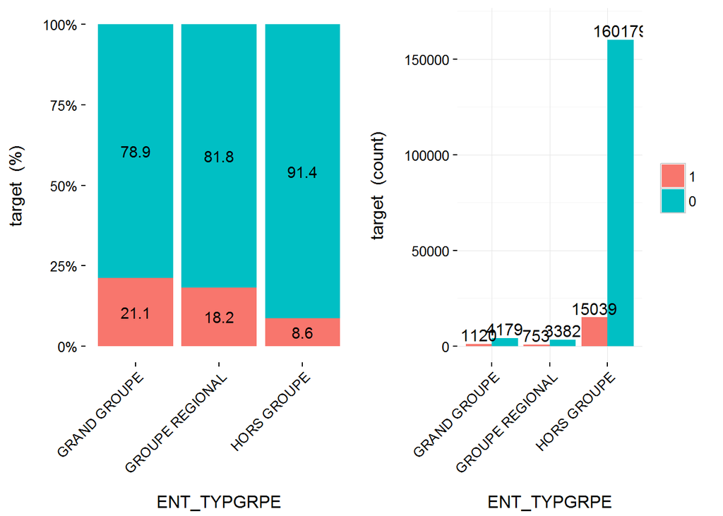

```r
library(funModeling)
cross_plot(data=df1, str_input = "ENT_TYPGRPE", str_target="target")
```

And now by other categorical variables

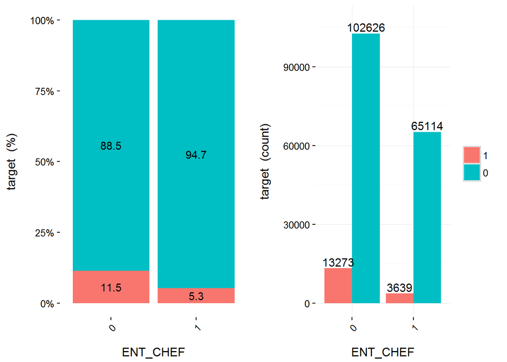

```r
cross_plot(data=df1, str_target="target", str_input = "ENT_CHEF")
```

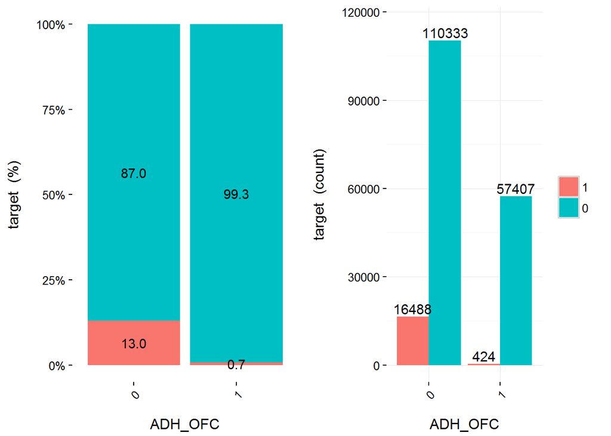

```r
cross_plot(data=df1, str_target="target", str_input = 'ADH_OFC')
```

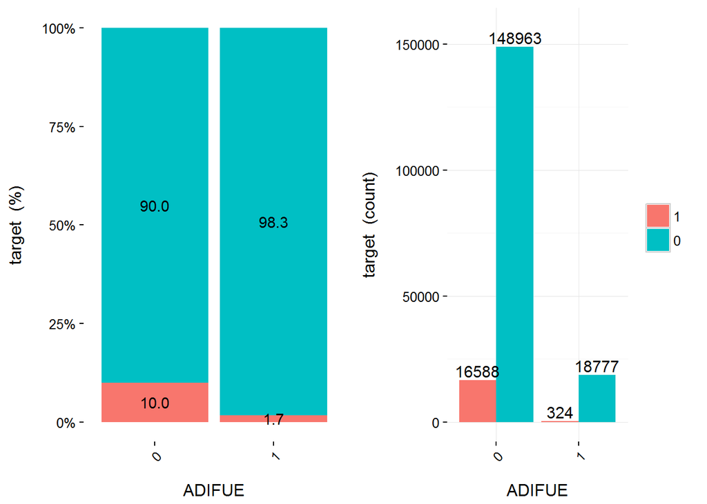

```r
cross_plot(data=df1, str_target="target", str_input = 'ADIFUE')
```

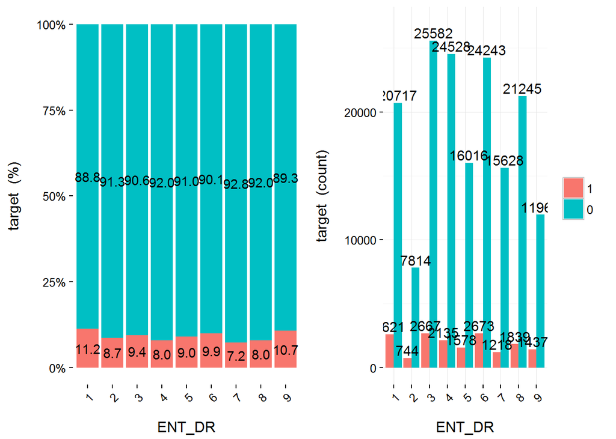

```r
cross_plot(data=df1, str_target="target", str_input = 'ENT_DR')
```

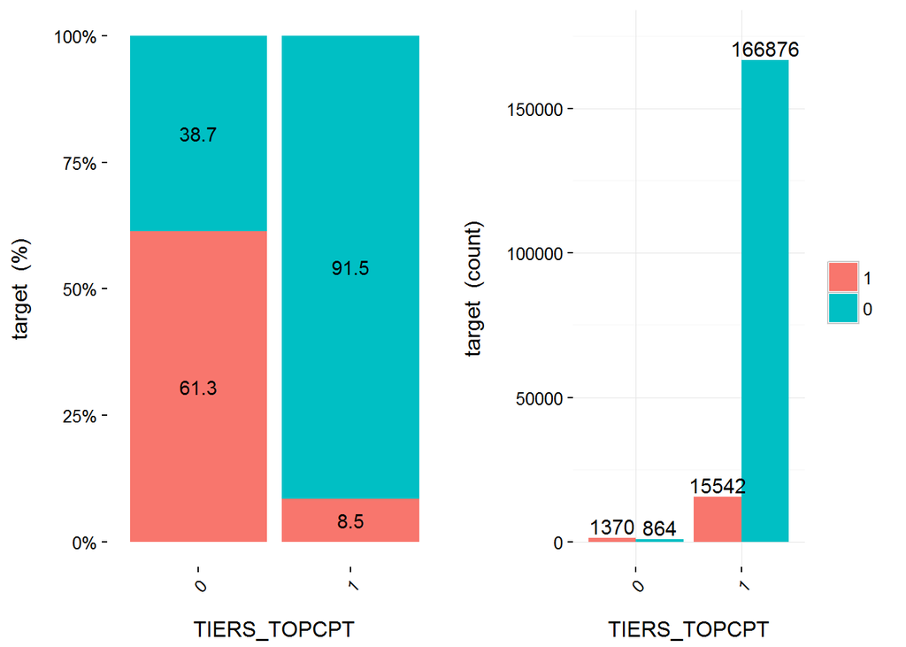

```r
cross_plot(data=df1, str_target="target", str_input = 'TIERS_TOPCPT')
```

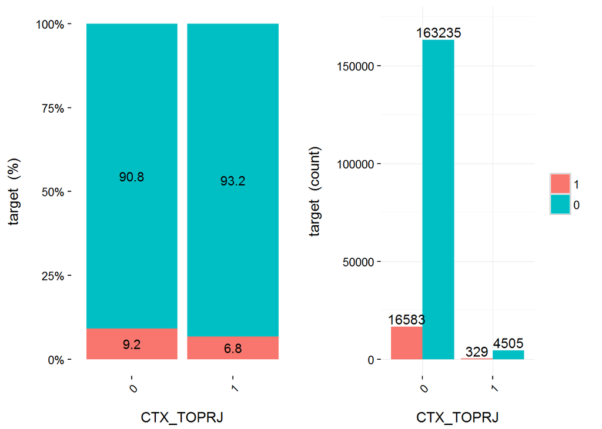

```r
cross_plot(data=df1, str_target="target", str_input = 'CTX_TOPRJ')
```

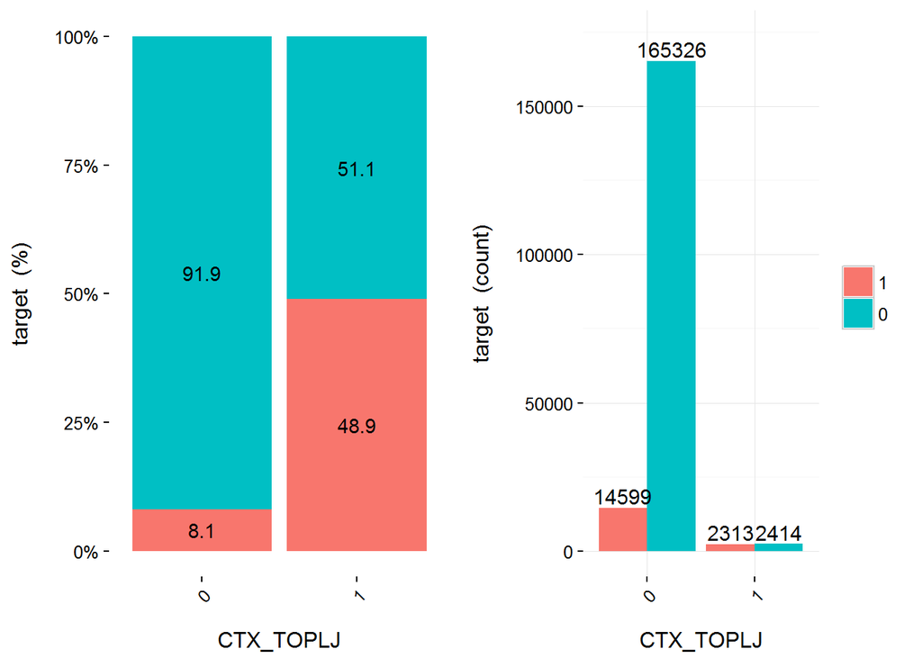

```r
cross_plot(data=df1, str_target="target", str_input = 'CTX_TOPLJ')
```

Making somme interpretations

- Is “CTX_LJ” a good predictor for the target of the model?

This variable seems to be a good predictor since the likelihood of having " Resilie =1 " is different given the CTX_LJ=0 or CTX_LJ=1 groups.The “Resilie” rate for CTX_LJ=1 is six times higher than the " Resilie" rate for CTX_LJ=0 (48.9% vs 8.1%, respectively).

- You can see that except “ENT_DR”,all other categorical variables seems to be relevant , since they seperate the target well.

Now, let’s make cross-plot by numeric variales

```
## [1] "Plotting transformed variable 'AFF_FM_TAUXSAL' with 'equal_freq', (too many values). Disable with 'auto_binning=FALSE'"
```

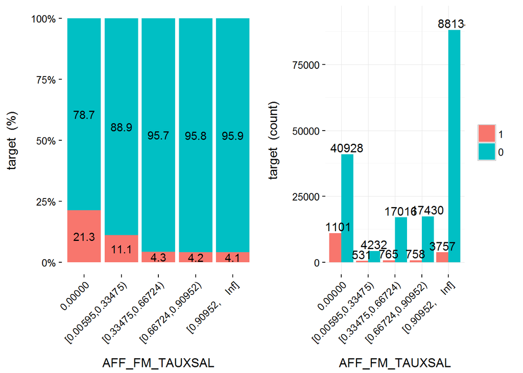

```
## [1] "Plotting transformed variable 'AFF_FM_NBSAL' with 'equal_freq', (too many values). Disable with 'auto_binning=FALSE'"
```

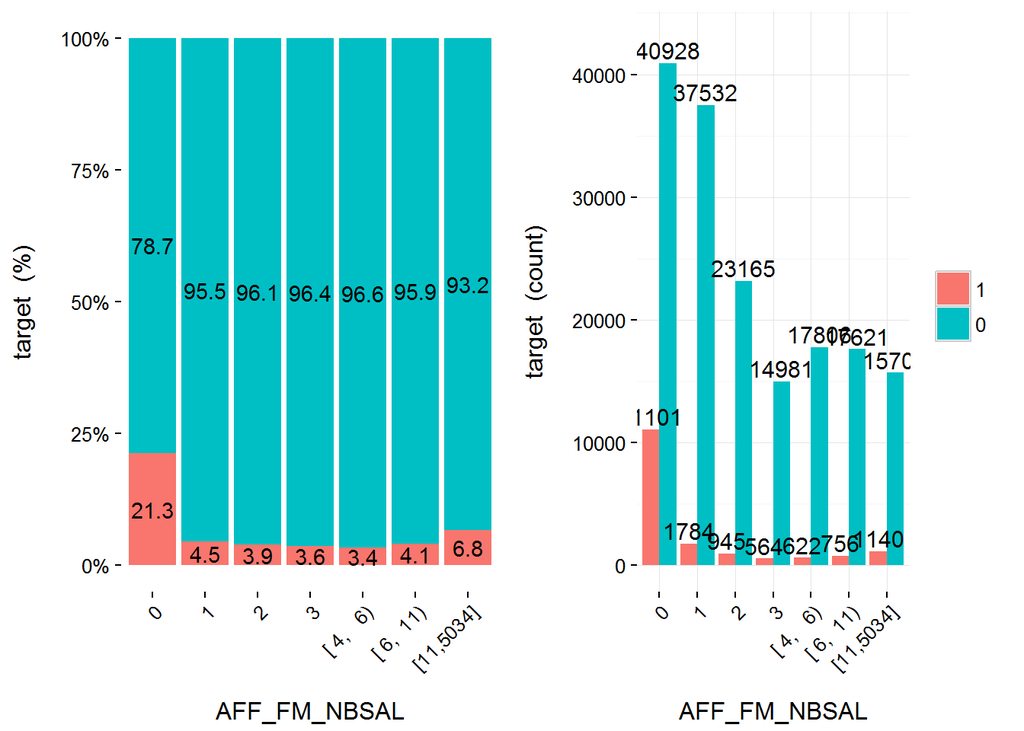

```
## [1] "Plotting transformed variable 'PRESTFM_N' with 'equal_freq', (too many values). Disable with 'auto_binning=FALSE'"
```

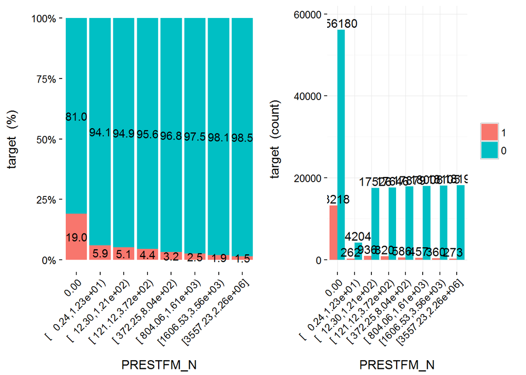

```
## [1] "Plotting transformed variable 'CGAFM_N' with 'equal_freq', (too many values). Disable with 'auto_binning=FALSE'"
```

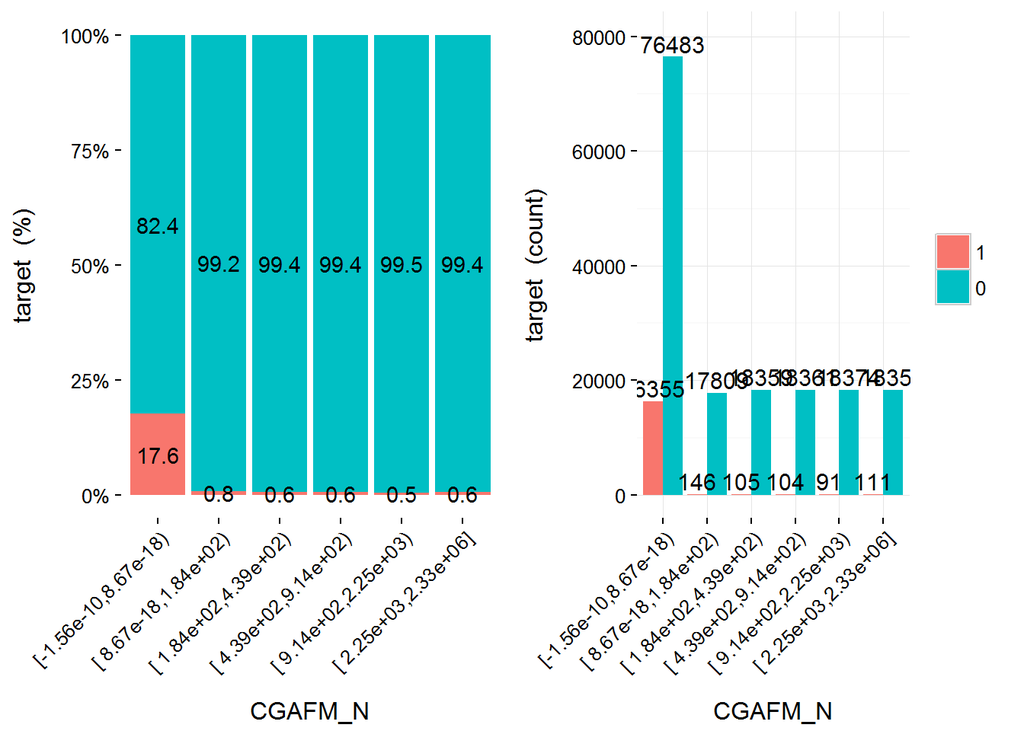

```
## [1] "Plotting transformed variable 'CTAD_NB_TELENTRANT' with 'equal_freq', (too many values). Disable with 'auto_binning=FALSE'"
```

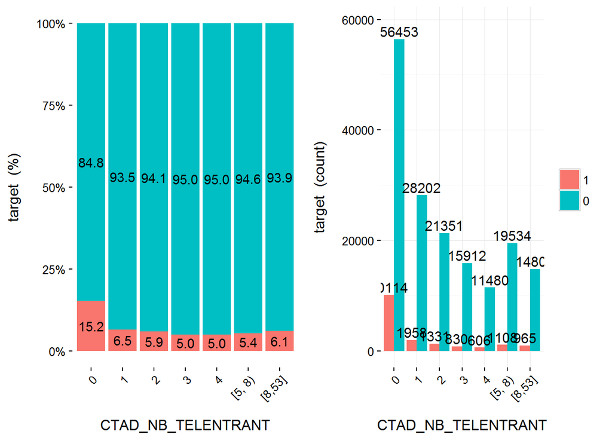

```
## [1] "Plotting transformed variable 'CTAD_NB_TELSORTANT' with 'equal_freq', (too many values). Disable with 'auto_binning=FALSE'"
```

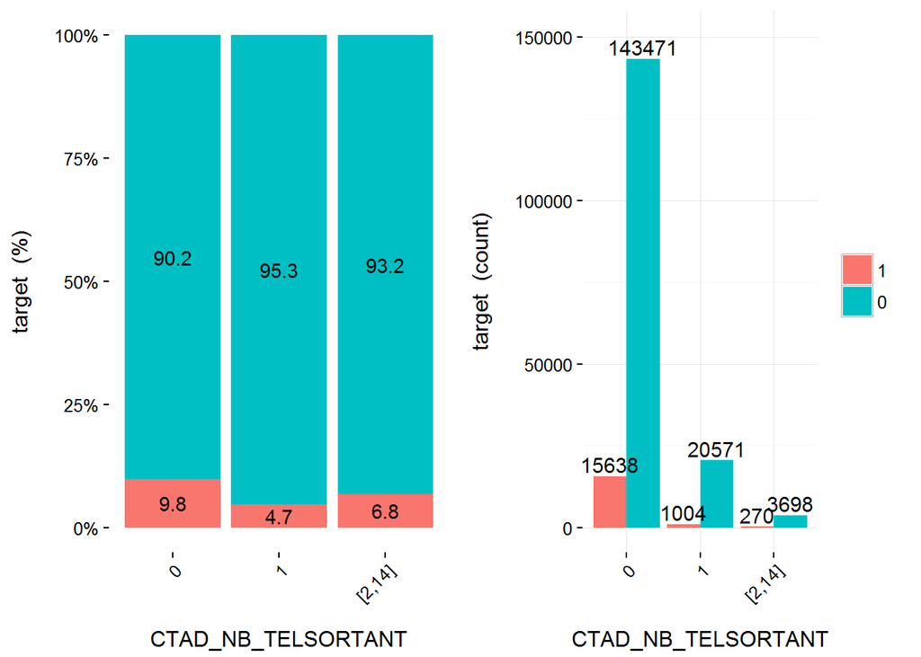

```
## [1] "Plotting transformed variable 'CTAD_DELAI_TELSORTANT' with 'equal_freq', (too many values). Disable with 'auto_binning=FALSE'"
```

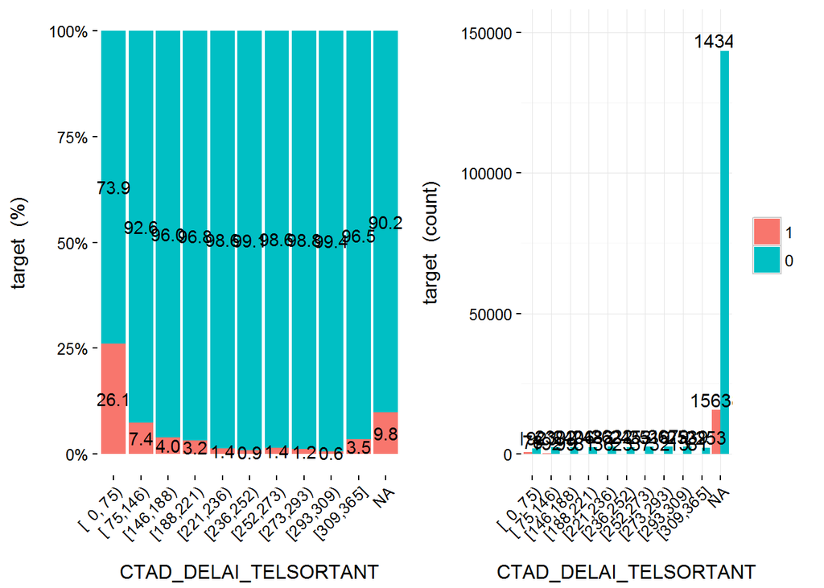

```
## [1] "Plotting transformed variable 'CTAD_NB_FM' with 'equal_freq', (too many values). Disable with 'auto_binning=FALSE'"
```

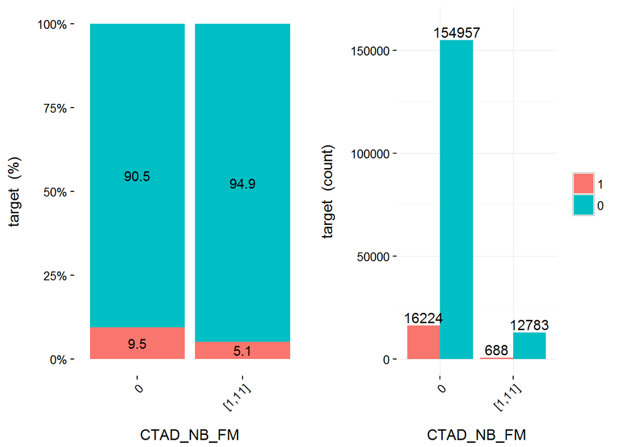

```
## [1] "Plotting transformed variable 'CTAD_NB_HORSFM' with 'equal_freq', (too many values). Disable with 'auto_binning=FALSE'"
```

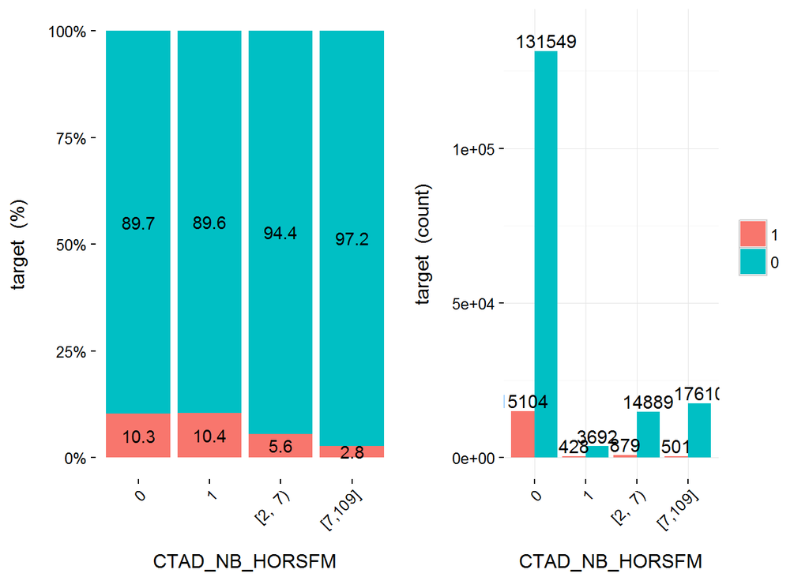

```
## [1] "Plotting transformed variable 'CTAD_DELAI_FM' with 'equal_freq', (too many values). Disable with 'auto_binning=FALSE'"
```

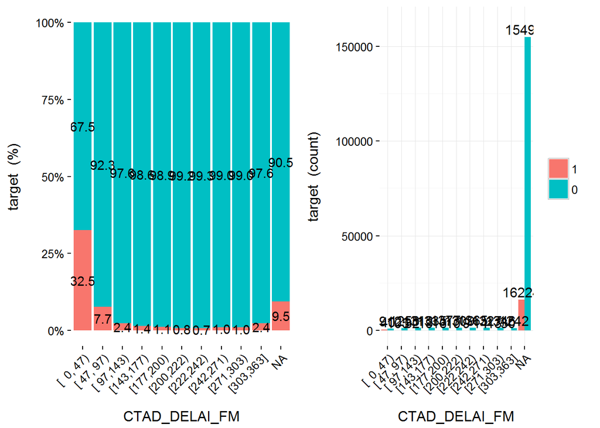

```
## [1] "Plotting transformed variable 'CTAD_DELAI_HORSFM' with 'equal_freq', (too many values). Disable with 'auto_binning=FALSE'"
```

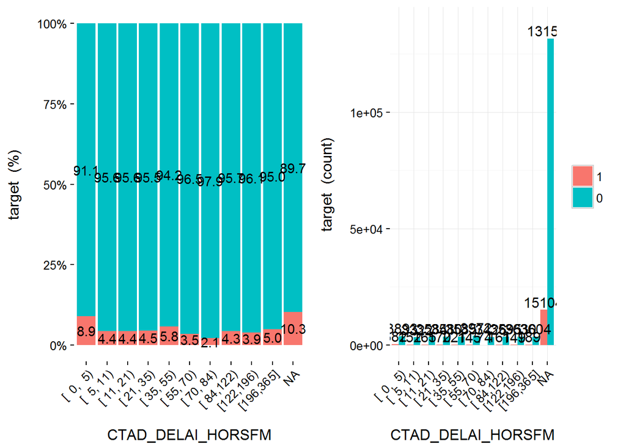

```
## [1] "Plotting transformed variable 'CTAD_NB_INA' with 'equal_freq', (too many values). Disable with 'auto_binning=FALSE'"
```

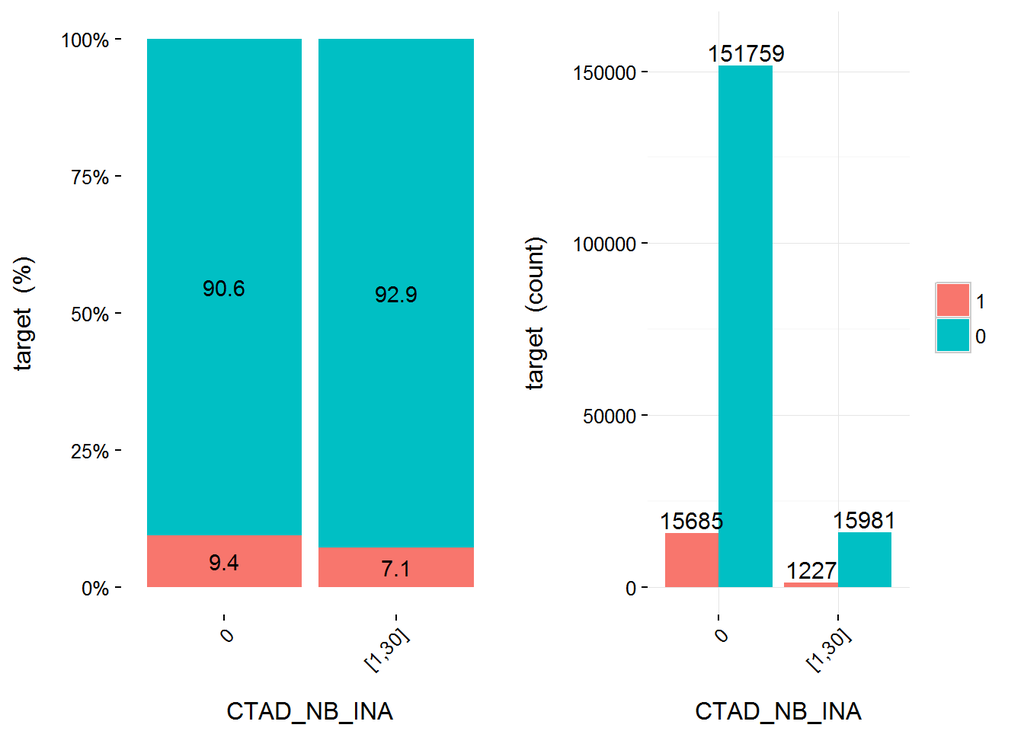

```
## [1] "Plotting transformed variable 'CTAD_DELAI_INA' with 'equal_freq', (too many values). Disable with 'auto_binning=FALSE'"
```

[17 more figures not shown]

```r
cross_plot(data=df1, str_target="target", str_input = c('AFF_FM_TAUXSAL','AFF_FM_NBSAL','PRESTFM_N','CGAFM_N',
             'CTAD_NB_TELENTRANT','CTAD_NB_TELSORTANT','CTAD_DELAI_TELSORTANT','CTAD_NB_FM',
             'CTAD_NB_HORSFM','CTAD_DELAI_FM','CTAD_DELAI_HORSFM','CTAD_NB_INA','CTAD_DELAI_INA','CTAD_NB_INAFM',
             'CTAD_DELAI_INAFM','CTCO_NB_FM','CTCO_DELAI_FM','CTCO_NB_HORSFM','CTCO_DELAI_HORSFM','CTCO_NB_VISITE',
             'CTCO_DELAI_VISITE','CTCO_NB_SIM','CTCO_DELAI_SIM','CTCO_NB_TELENTRANT','CTCO_DELAI_TELENTRANT',
             'CTCO_NB_TELSORTANT','CTCO_DELAI_TELSORTANT','ENT_ANCIENNETE','ADH_DUREE'),auto_binning = TRUE)
```

Somme more interpretations

- ENT_Anciennete shows a linear and positive relationship with the Target ( value at N < value at N+1 ). However, the bucket 2138-3044 adds a little noise in this relationship.
- The more CTAD_delai_INAFM is recent, the more there are cancelled contracts ( see the 2 first buckets at the first glance)
- No commercial visite seems to have a positive correlation to contract cancellation ( see CTCO_NB_VISITE at the bucket 0 where the number of cancelled contracts increase to 11.9% )

Now, we will make somme Density Histograms for refleting mean differencies instead of statistical test

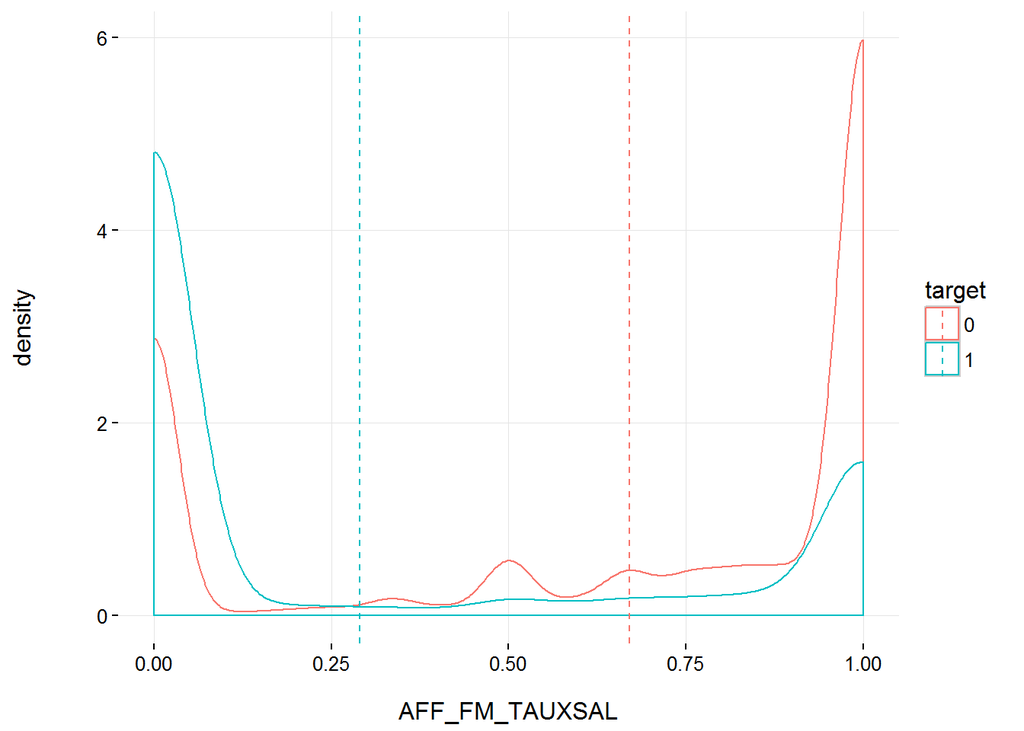

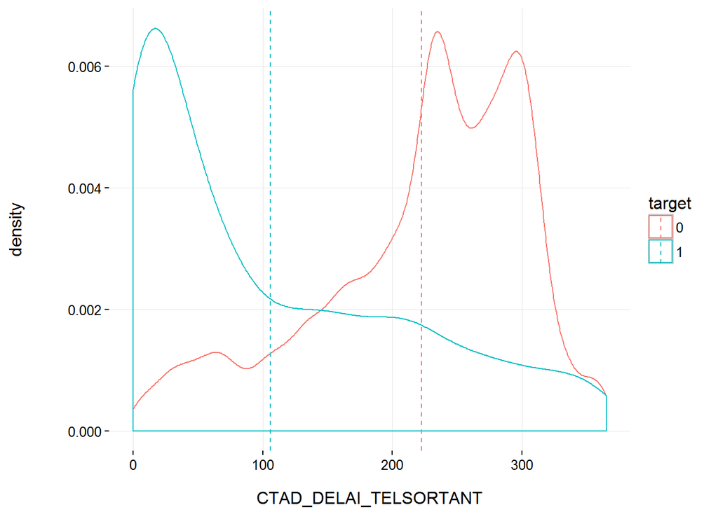

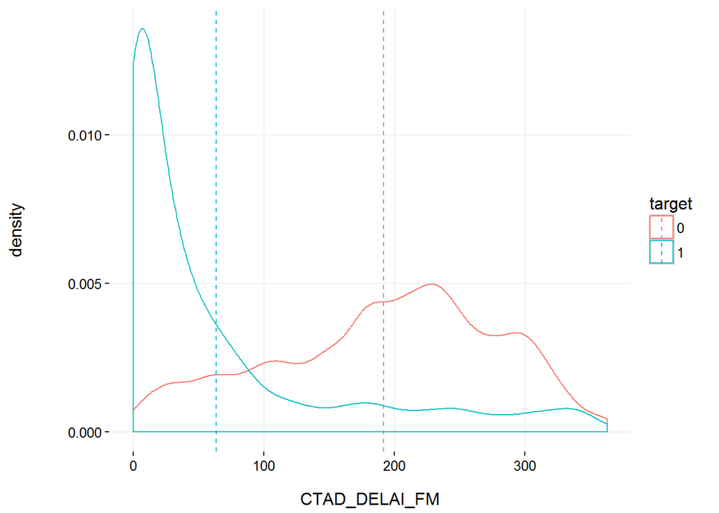

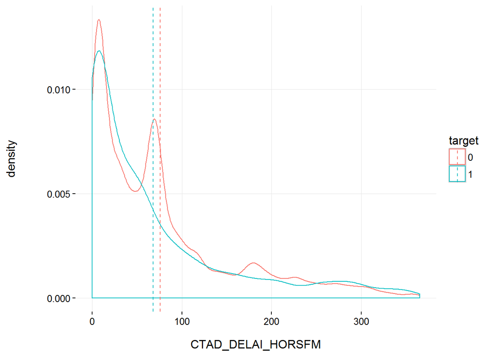

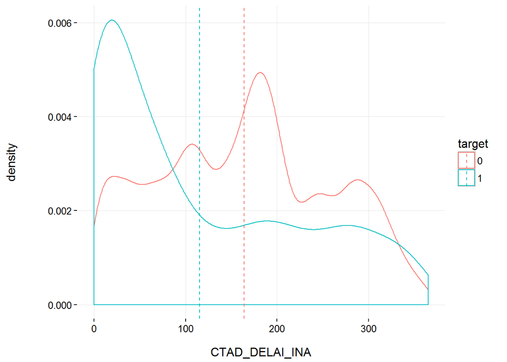

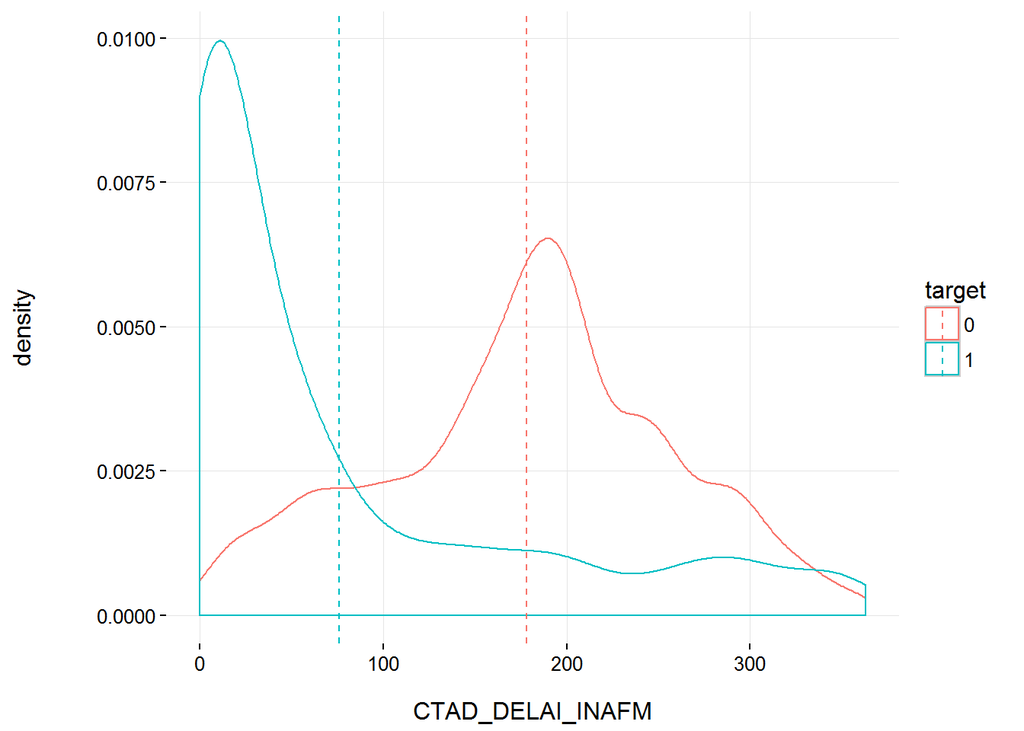

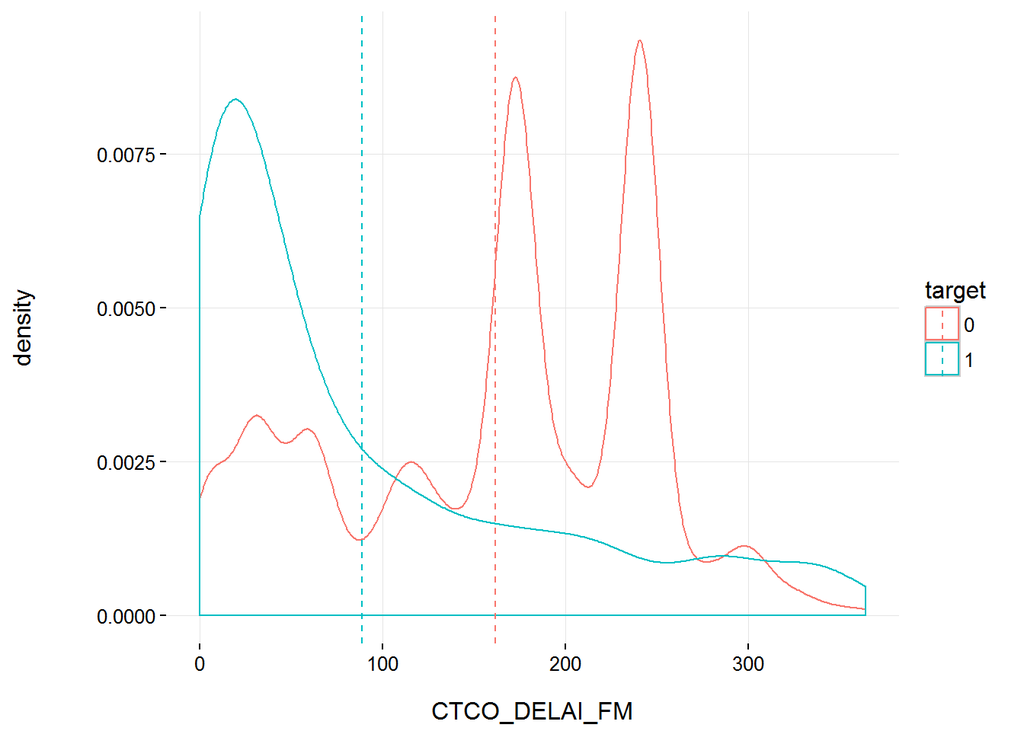

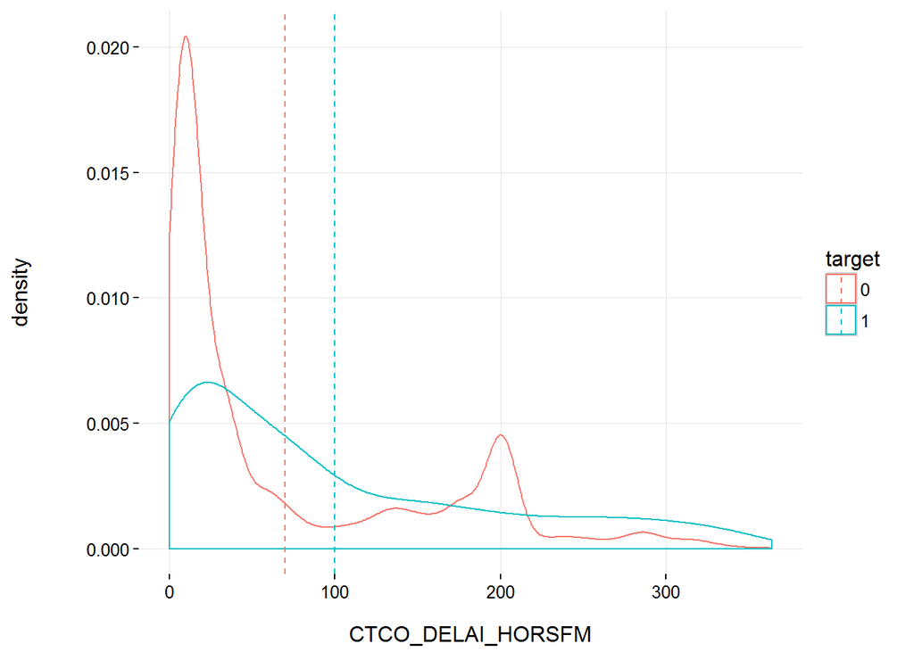

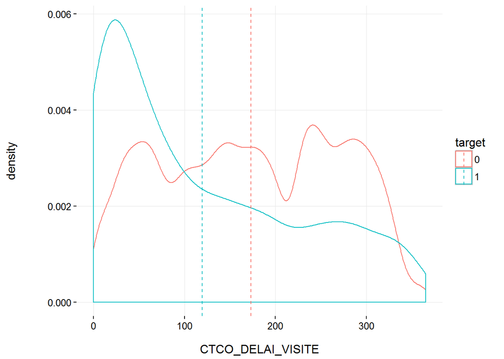

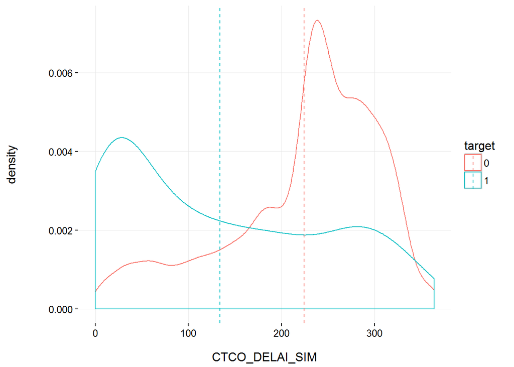

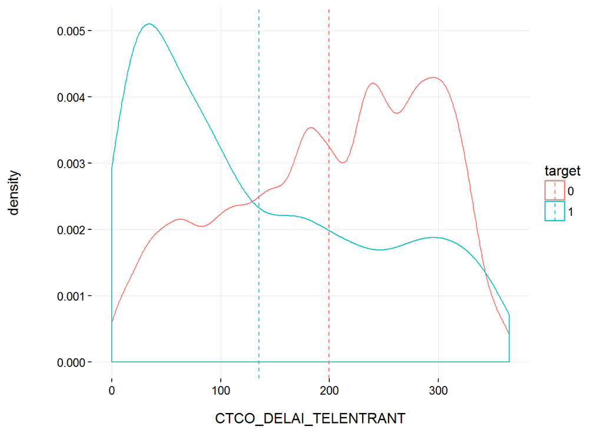

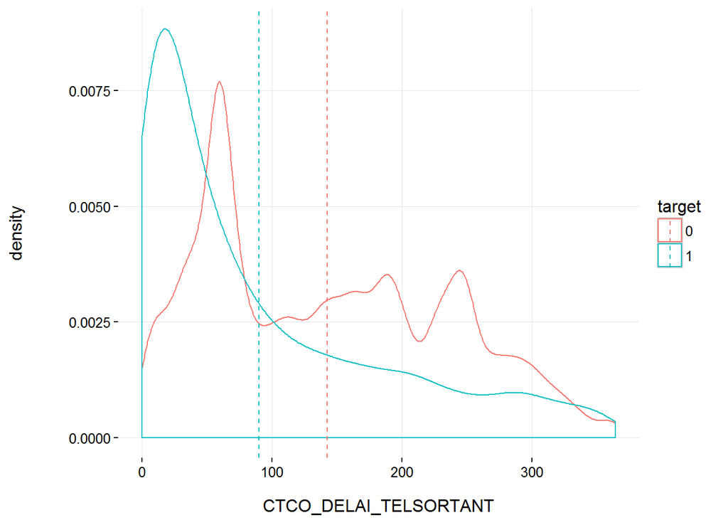

[2 more figures not shown]

```r
library(funModeling)
plotar(data=df1, str=c('AFF_FM_TAUXSAL',
             'CTAD_DELAI_TELSORTANT',
             'CTAD_DELAI_FM','CTAD_DELAI_HORSFM','CTAD_DELAI_INA',
             'CTAD_DELAI_INAFM','CTCO_DELAI_FM','CTCO_DELAI_HORSFM',
             'CTCO_DELAI_VISITE','CTCO_DELAI_SIM','CTCO_DELAI_TELENTRANT',
             'CTCO_DELAI_TELSORTANT','ENT_ANCIENNETE','ADH_DUREE'),str_target="target", plot_type = "histdens")
```